# week3 Milestone Report

Michael Garcia

2023-05-21

The goal of this project is just to display that you’ve gotten used to working with the data and that you are on track to create your prediction algorithm. Please submit a report on R Pubs (http://rpubs.com/) that explains your exploratory analysis and your goals for the eventual app and algorithm. This document should be concise and explain only the major features of the data you have identified and briefly summarize your plans for creating the prediction algorithm and Shiny app in a way that would be understandable to a non-data scientist manager. You should make use of tables and plots to illustrate important summaries of the data set.

### The motivation for this project is to:

1. Demonstrate that you’ve downloaded the data and have successfully loaded it in.
2. Create a basic report of summary statistics about the data sets.
3. Report any interesting findings that you amassed so far.
4. Get feedback on your plans for creating a prediction algorithm and Shiny app.

### Tasks

1. Review criteria less Does the link lead to an HTML page describing the exploratory analysis of the training data set?
2. Has the data scientist done basic summaries of the three files? Word counts, line counts and basic data tables?
3. Has the data scientist made basic plots, such as histograms to illustrate features of the data?
4. Was the report written in a brief, concise style, in a way that a non-data scientist manager could appreciate?

```r
textdata <- setRefClass("textdata",
                        fields = list(filepath="character", linecount="ANY", charcount="ANY", wordratio="ANY", wordsearchres="ANY", statementcount="ANY", dfwrangle="ANY", wordplot="ANY"),
                        methods = list(
                          initialize = function(filepath) {
                            .self$filepath <- filepath
                            .self$linecount <- .self$lineCounter()
                            .self$charcount <- .self$charCounter(countbreak = 0)
                            .self$wordratio <- .self$wordDiv()
                            .self$wordsearchres <- .self$wordSearch()
                            .self$statementcount <- .self$statementCount()
                            .self$dfwrangle  <- .self$datawrangle()
                            .self$wordplot <- .self$wordPlot()
                          },

                          lineCounter = function(.self){
                            f <- file(.self$filepath, open="rb")
                            nlines <- 0L
                            while (length(chunk <- readBin(f, "raw", 65536)) > 0){
                              nlines <- nlines + sum(chunk == as.raw(10L))
                            }
                            close(f)
                            sprintf("The file has %s lines.", nlines)
                            return(nlines)
                          }
                          ,
                          charCounter = function(.self,countbreak=NULL){
                            if (is.null(countbreak)==TRUE){
                              return(NULL)
                            } else {
                              counter = 0
                              charct = 0L
                              for (line in readLines(.self$filepath)){
                                #print(line)
                                current <-  nchar(line)
                                if (current > charct){
                                  charct = current
                                }
                                counter = counter + 1
                                if (counter == countbreak & countbreak !=0){
                                  break
                                }
                              }
                              .self$charcount = charct
                              return(charct)
                            }
                          }
                          ,
                          wordDiv = function(.self,word1=NULL,word2=NULL){
                            if (is.null(word1)==TRUE || is.null(word2)==TRUE){
                              return(NULL)
                            } else {
                              f <- file(.self$filepath, open="rb")
                              filelines <- readLines(f)
                              div <- length(grep(word1, filelines))/length(grep(word2, filelines))
                              #print(div)
                              close(f)
                              sprintf("We get %s",div)
                              .self$wordratio = div
                              return(div)
                            }
                          }
                          ,
                          wordSearch = function(.self,word=NULL){
                            if (is.null(word)==TRUE){
                              return(NULL)
                            } else {
                              f <- file(.self$filepath, open="rb")
                              filelines <- readLines(f)
                              res <- grep(word, filelines, value = T)
                              close(f)
                              print(res)
                              .self$wordsearchres = res
                              return(res)
                            }
                          }
                          ,
                          statementCount = function(.self,statement=NULL){
                            if (is.null(statement)==TRUE){
                              return(NULL)
                            } else{
                              f <- file(.self$filepath, open="rb")
                              filelines <- readLines(f)
                              lns <- grep(statement, filelines)
                              close(f)
                              sprintf("Frequency of statement %s", length(lns))
                              .self$statementcount = lns
                              return(lns)
                            }
                          }
                          ,
                          datawrangle = function(.self){
                            strfile <- readLines(.self$filepath)
                            df_source <- tibble(line = 1:length(strfile), text = strfile)

                            df_source_unnest <- df_source %>%
                                   unnest_tokens(word, text) %>%
                                   mutate(source = toString(.self$filepath))

                            #Clean out numbers
                            df_source_unnest <- df_source_unnest %>% filter(!grepl("[0-9]", word))
                            df <- df_source_unnest

                            df <- df %>% anti_join(stop_words, by = "word")
                            return(df)
                          }
                          ,
                          wordPlot = function(.self){
                            df <- .self$dfwrangle
                            df_wordcount <- df %>% count(word, sort = TRUE)
                            df_wordcount %>% head(n = 20) %>% mutate(word = reorder(word, n)) %>%

                                   ggplot(aes(x = n, y = word)) +
                                   geom_col(fill = "#00abff") +
                                   theme_bw() +
                                   ggtitle("Most frequently used words in the English language")
                          }
                        )
                        )

combineTibbles <- function(tib1,tib2,tib3){
    df <- rbind(tib1, tib2, tib3)
}
```

### Read data and instantiate objects containing results

Prior to initiating the file read, mkdir named “final” and download and extract into the final directory.

```r
blogsfile = "./final/en_us/en_US.blogs.txt"
newsfile = "./final/en_us/en_US.news.txt"
twitfile = "./final/en_us/en_US.twitter.txt"


blogsinfo <- textdata(blogsfile)
newsinfo <- textdata(newsfile)
twitinfo <- textdata(twitfile)
```

## Summary for blogs file

```r
print("Word Count: ")
```

[output not shown]

```r
print(blogsinfo$charcount)
```

```
## [1] 40833
```

```r
print("Line Count: ")
```

```
## [1] "Line Count: "
```

```r
print(blogsinfo$linecount)
```

```
## [1] 899288
```

### Blogs Plot

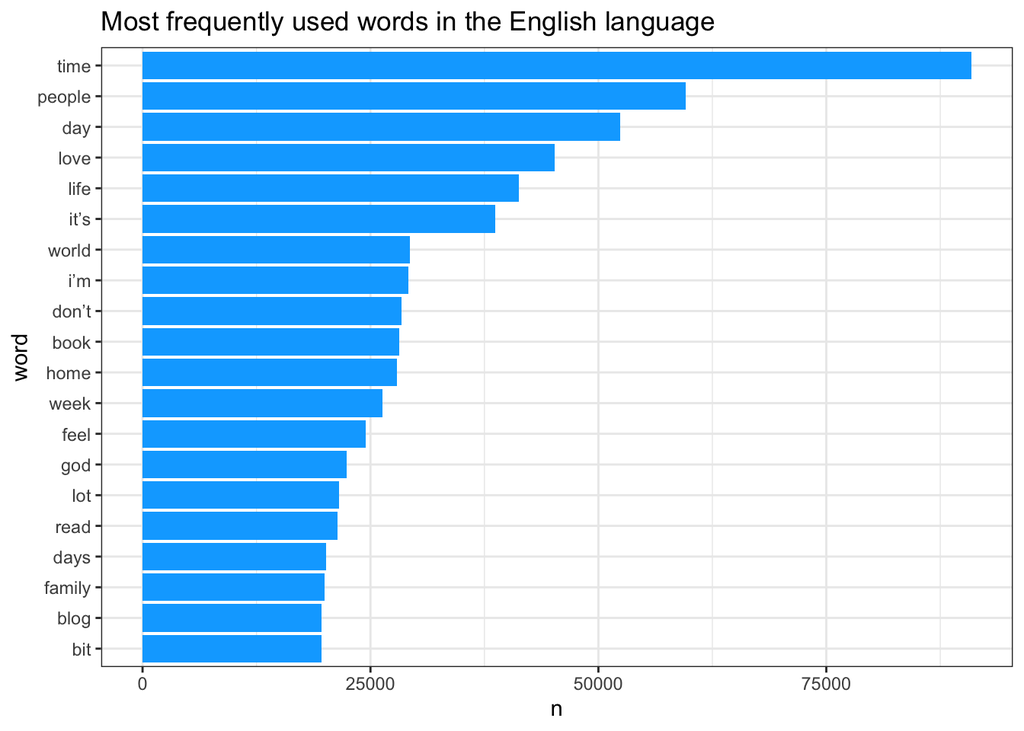

```r
blogsinfo$wordplot
```

## Summary for newsinfo

```r
print("Word Count: ")
```

[output not shown]

```r
print(newsinfo$charcount)
```

```
## [1] 11384
```

```r
print("Line Count: ")
```

```
## [1] "Line Count: "
```

```r
print(newsinfo$linecount)
```

```
## [1] 1010242
```

### News Word Plot

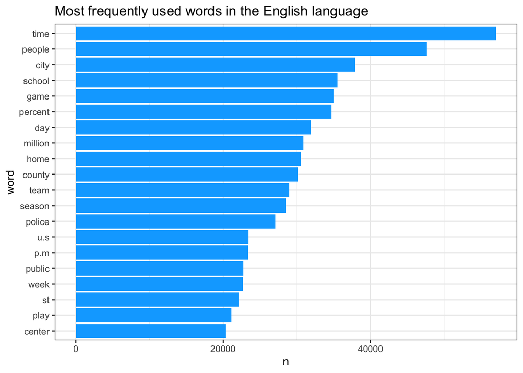

```r
newsinfo$wordplot
```

## Summary for twitter

```r
print("Word Count: ")
```

[output not shown]

```r
print(twitinfo$charcount)
```

```
## [1] 140
```

```r
print("Line Count: ")
```

```
## [1] "Line Count: "
```

```r
print(twitinfo$linecount)
```

```
## [1] 2360148
```

### twitter plot

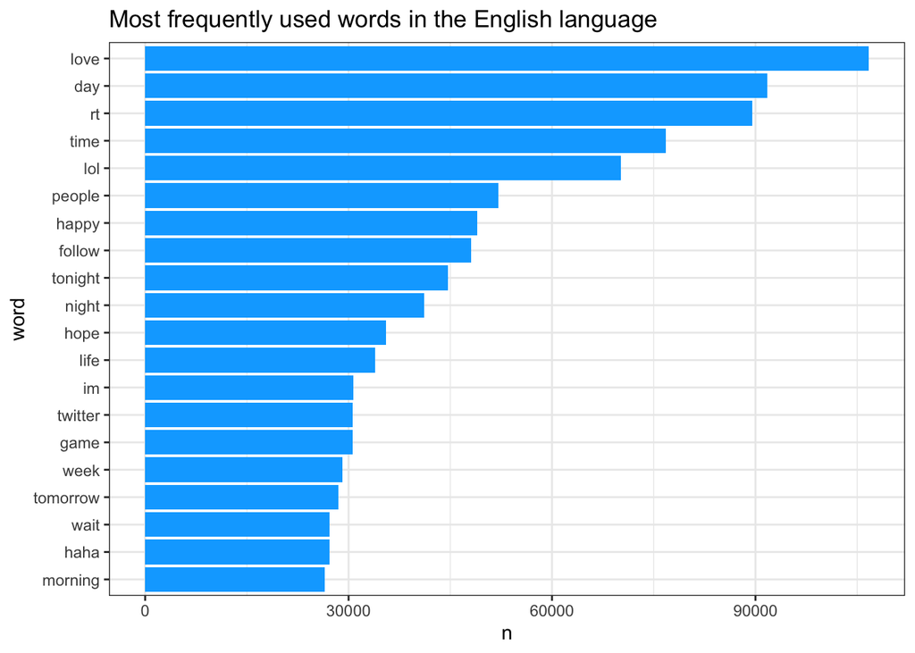

```r
twitinfo$wordplot
```

```r
# merge the dataframes
dfbind <- combineTibbles(blogsinfo$dfwrangle, newsinfo$dfwrangle, twitinfo$dfwrangle)
## Copy an instantiazed class
updatetext <- newsinfo
updatetext$dfwrangle <- dfbind


print("Word Count: ")
```

[output not shown]

```r
print(updatetext$charcount)
```

```
## [1] 11384
```

```r
print("Line Count: ")
```

```
## [1] "Line Count: "
```

```r
print(updatetext$linecount)
```

```
## [1] 1010242
```

### All Source Word Frequency

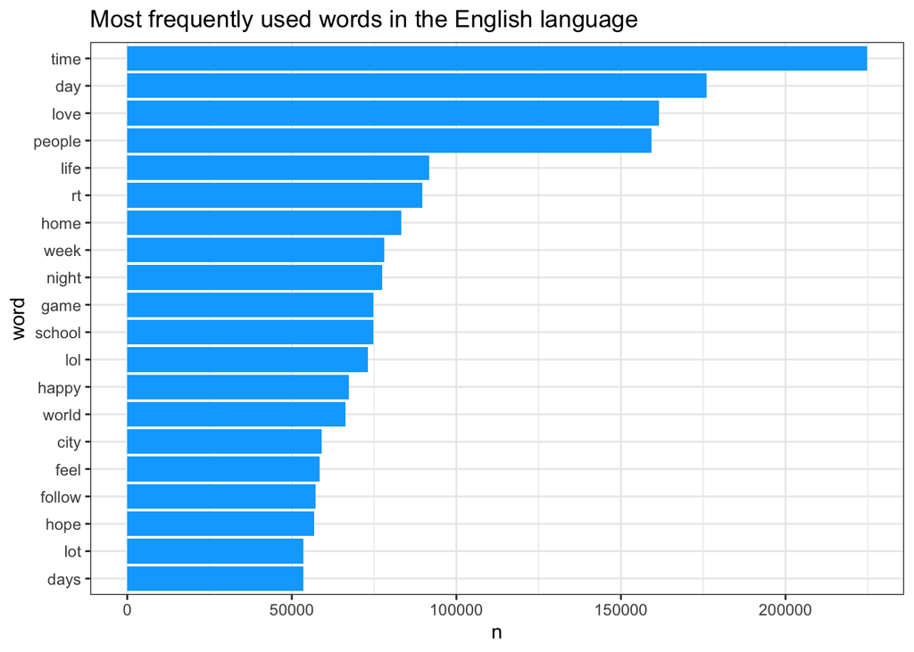

```r
updatetext$wordPlot()
```